# Análise descritiva e estatística de uma base de dados

Maria Sobreira

2025-04-10

### **PROJETO DA DISCIPLINA**

### Análise de Dados

#### Aluno: MARIA CLARA SILVA SOBREIRA

Nessa disciplina, foram somados ao conhecimento de anáise exploratória de dados, aspectos importantes do dia a dia de um cientista de dados: distribuição dos dados, imputação de dados, visualização de dados, construção de dashboards e relatórios.

#### Base de dados

A escolha do dataset de vinhos foi motivada pela possibilidade de analisar as variáveis que representam características físico-químicas de vinhos, como teor alcoólico, acidez e compostos fenólicos. Essa base é comumente utilizada para a classificação de vinhos em 3 tipos, mas neste trabalho o foco está na análise exploratória dos dados, tal como é o proposto para a disciplina.

Dessa maneira, espera-se encontrar insights a partir das variáveis Álcool, Acidez Málica, Intensidade da cor e dos compostos fenólicos (Total_Phenols e Flavanoids). Também espera-se analisar as estatísticas descritivas de variáveis numéricas, como:

- média do teor alcoólico, indicando vinhos mais fortificados ou suaves;
- dispersão da acidez málica, verificando as diferenças significativas entre os vinhos; e,
- correlação entre as variáveis Phenols e Flavanoids, pois vinhos com mais fenólicos tendem a ser mais adstringentes.

```
##  [1] "Alcohol"              "Malic_Acid"           "Ash"
##  [4] "Ash_Alcanity"         "Magnesium"            "Total_Phenols"
##  [7] "Flavanoids"           "Nonflavanoid_Phenols" "Proanthocyanins"
## [10] "Color_Intensity"      "Hue"                  "OD280"
## [13] "Proline"
```

- Apresentando as primeiras linhas do banco de dados de Vinhos.

|  | Alcohol | Malic_Acid | Total_Phenols | Flavanoids | Color_Intensity |
| --- | --- | --- | --- | --- | --- |
| 1 | 14.23 | 1.71 | 2.80 | 3.06 | 5.64 |
| 2 | 13.20 | 1.78 | 2.65 | 2.76 | 4.38 |
| 3 | 13.16 | 2.36 | 2.80 | 3.24 | 5.68 |
| 4 | 14.37 | 1.95 | 3.85 | 3.49 | 7.80 |
| 5 | 13.24 | 2.59 | 2.80 | 2.69 | 4.32 |
| 6 | 14.20 | 1.76 | 3.27 | 3.39 | 6.75 |

```
##     Alcohol        Malic_Acid    Total_Phenols     Flavanoids
##  Min.   :11.03   Min.   :0.740   Min.   :0.980   Min.   :0.340
##  1st Qu.:12.36   1st Qu.:1.603   1st Qu.:1.742   1st Qu.:1.205
##  Median :13.05   Median :1.865   Median :2.355   Median :2.135
##  Mean   :13.00   Mean   :2.336   Mean   :2.295   Mean   :2.029
##  3rd Qu.:13.68   3rd Qu.:3.083   3rd Qu.:2.800   3rd Qu.:2.875
##  Max.   :14.83   Max.   :5.800   Max.   :3.880   Max.   :5.080
##  Color_Intensity
##  Min.   : 1.280
##  1st Qu.: 3.220
##  Median : 4.690
##  Mean   : 5.058
##  3rd Qu.: 6.200
##  Max.   :13.000
```

## Identificando os tipos de cada variável na base

- A função diagnose foi utilizada para identificar tipos de variável, unicidade e proporção de *missing values*.

Como a base original não possui dados faltantes, precisei gerar valoros vazios (aleatoriamente) para a variável “Malic_Acid”.

| variables | types | missing_count | missing_percent | unique_count | unique_rate |
| --- | --- | --- | --- | --- | --- |
| Alcohol | numeric | 0 | 0.000000 | 126 | 0.7078652 |
| Malic_Acid | numeric | 17 | 9.550562 | 127 | 0.7134831 |
| Total_Phenols | numeric | 0 | 0.000000 | 97 | 0.5449438 |
| Flavanoids | numeric | 0 | 0.000000 | 132 | 0.7415730 |
| Color_Intensity | numeric | 0 | 0.000000 | 132 | 0.7415730 |

| variables | types | missing_count | missing_percent | unique_count | unique_rate |
| --- | --- | --- | --- | --- | --- |
| Malic_Acid | numeric | 17 | 9.550562 | 127 | 0.7134831 |

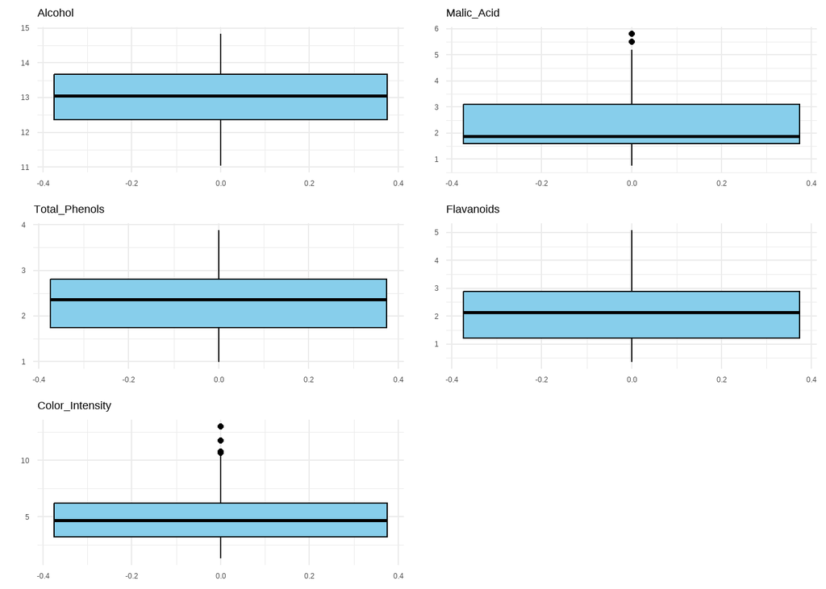

## Análise de frequências da variável **Ácido Málico** (com dados faltantes)

- Utilizado a função freq() do pacote summarytools para calcular as frequências relativas

As variáveis Alcool e Total_Phenols apresentam as frequencias semelhantes a uma distribuição normal.

|  | Freq | % Valid | % Valid Cum. | % Total | % Total Cum. |
| --- | --- | --- | --- | --- | --- |
| **0.74** | 1 | 0.62 | 0.62 | 0.56 | 0.56 |
| **0.89** | 1 | 0.62 | 1.24 | 0.56 | 1.12 |
| **0.9** | 1 | 0.62 | 1.86 | 0.56 | 1.69 |
| **0.92** | 1 | 0.62 | 2.48 | 0.56 | 2.25 |
| **0.94** | 2 | 1.24 | 3.73 | 1.12 | 3.37 |
| **0.98** | 1 | 0.62 | 4.35 | 0.56 | 3.93 |
| **0.99** | 1 | 0.62 | 4.97 | 0.56 | 4.49 |
| **1.01** | 1 | 0.62 | 5.59 | 0.56 | 5.06 |
| **1.09** | 1 | 0.62 | 6.21 | 0.56 | 5.62 |
| **1.1** | 1 | 0.62 | 6.83 | 0.56 | 6.18 |
| **1.13** | 2 | 1.24 | 8.07 | 1.12 | 7.30 |
| **1.17** | 1 | 0.62 | 8.70 | 0.56 | 7.87 |
| **1.19** | 1 | 0.62 | 9.32 | 0.56 | 8.43 |
| **1.21** | 1 | 0.62 | 9.94 | 0.56 | 8.99 |
| **1.24** | 1 | 0.62 | 10.56 | 0.56 | 9.55 |
| **1.25** | 1 | 0.62 | 11.18 | 0.56 | 10.11 |
| **1.29** | 2 | 1.24 | 12.42 | 1.12 | 11.24 |
| **1.34** | 1 | 0.62 | 13.04 | 0.56 | 11.80 |
| **1.35** | 3 | 1.86 | 14.91 | 1.69 | 13.48 |
| **1.36** | 1 | 0.62 | 15.53 | 0.56 | 14.04 |
| **1.39** | 1 | 0.62 | 16.15 | 0.56 | 14.61 |
| **1.41** | 1 | 0.62 | 16.77 | 0.56 | 15.17 |
| **1.43** | 1 | 0.62 | 17.39 | 0.56 | 15.73 |
| **1.45** | 1 | 0.62 | 18.01 | 0.56 | 16.29 |
| **1.47** | 1 | 0.62 | 18.63 | 0.56 | 16.85 |
| **1.48** | 1 | 0.62 | 19.25 | 0.56 | 17.42 |
| **1.5** | 2 | 1.24 | 20.50 | 1.12 | 18.54 |
| **1.51** | 1 | 0.62 | 21.12 | 0.56 | 19.10 |
| **1.52** | 1 | 0.62 | 21.74 | 0.56 | 19.66 |
| **1.53** | 3 | 1.86 | 23.60 | 1.69 | 21.35 |

[output cut: 98 more lines]

Pela frequência relativa, nota-se que 9,5% (17 das 178 observações) dos dados de **ácido málico** estão sem valor na base de Vinhos e 30% dos dados apresentam valores em torno de 1,67.

## Análise descritiva e de histogramas de uma variável contínua

- Variável Alcool é analisada descritivamente.
- A centralidade dos dados, a dipersão, a assimetria, bem como as estatísticas de ordem são calculadas, a fim de ter uma leitura acerca da distribuição dessa variável.

Com relação aos ácidos málicos, a média é de 2.33, com valor mínimo de 0.74 e máximo de 5.80. Além disso, os as distâncias entre quartis, indicam uma grande dispersão dos dados. Assim, temos diferenças significativas entre os vinhos (características e propriedades de composição).

### Descriptive Statistics

#### wine$Alcohol

**N:** 178

|  | Alcohol |
| --- | --- |
| **Mean** | 13.00 |
| **Std.Dev** | 0.81 |
| **Min** | 11.03 |
| **Q1** | 12.36 |
| **Median** | 13.05 |
| **Q3** | 13.68 |
| **Max** | 14.83 |
| **MAD** | 1.01 |
| **IQR** | 1.32 |
| **CV** | 0.06 |
| **Skewness** | -0.05 |
| **SE.Skewness** | 0.18 |
| **Kurtosis** | -0.89 |
| **N.Valid** | 178.00 |
| **N** | 178.00 |
| **Pct.Valid** | 100.00 |

### Descriptive Statistics

#### wine$Malic_Acid

**N:** 178

|  | Malic_Acid |
| --- | --- |
| **Mean** | 2.33 |
| **Std.Dev** | 1.09 |
| **Min** | 0.74 |
| **Q1** | 1.60 |
| **Median** | 1.87 |
| **Q3** | 3.10 |
| **Max** | 5.80 |
| **MAD** | 0.79 |
| **IQR** | 1.50 |
| **CV** | 0.47 |
| **Skewness** | 0.95 |
| **SE.Skewness** | 0.19 |
| **Kurtosis** | 0.09 |
| **N.Valid** | 161.00 |
| **N** | 178.00 |
| **Pct.Valid** | 90.45 |

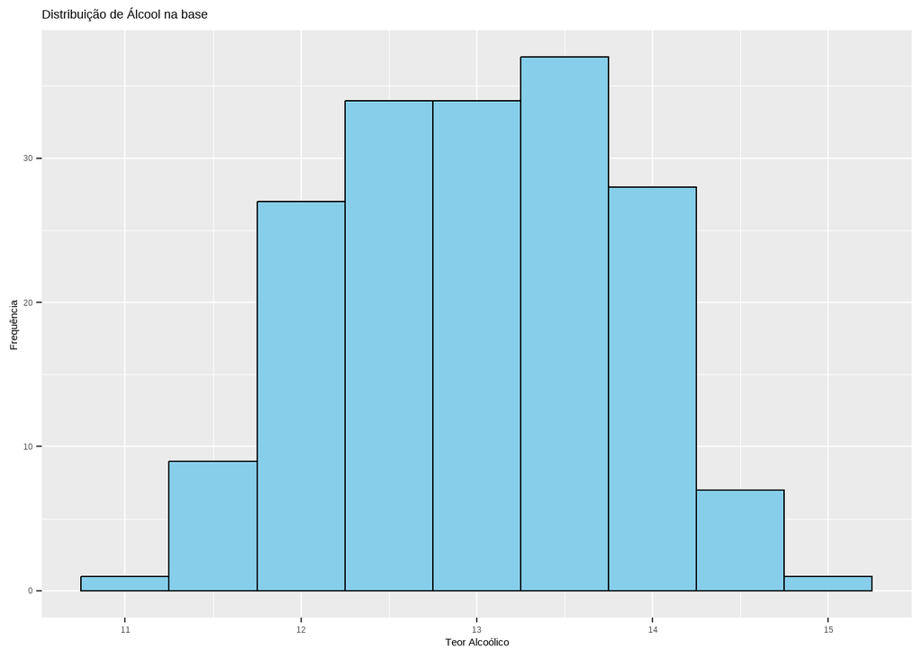

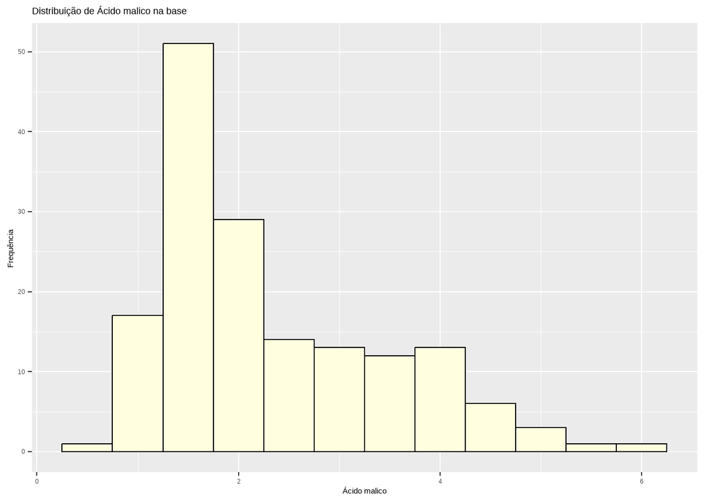

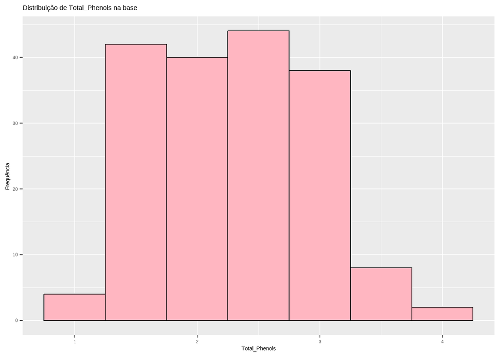

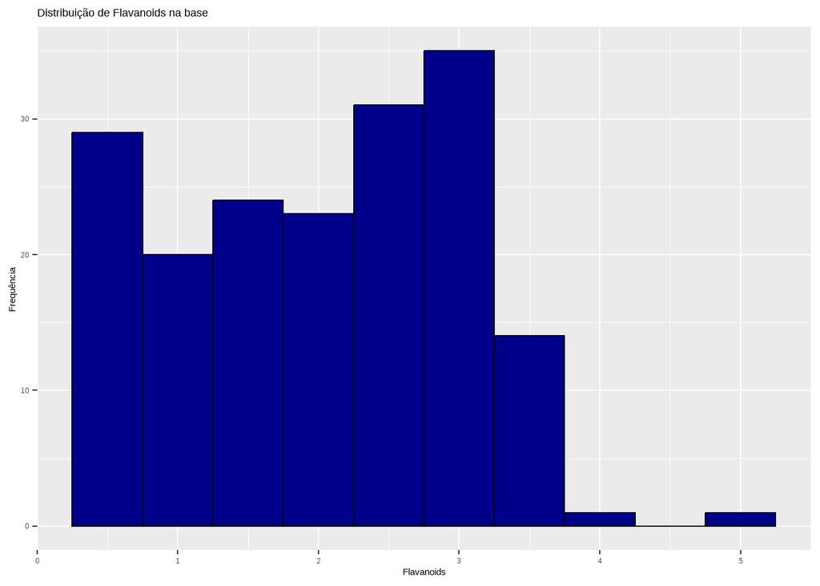

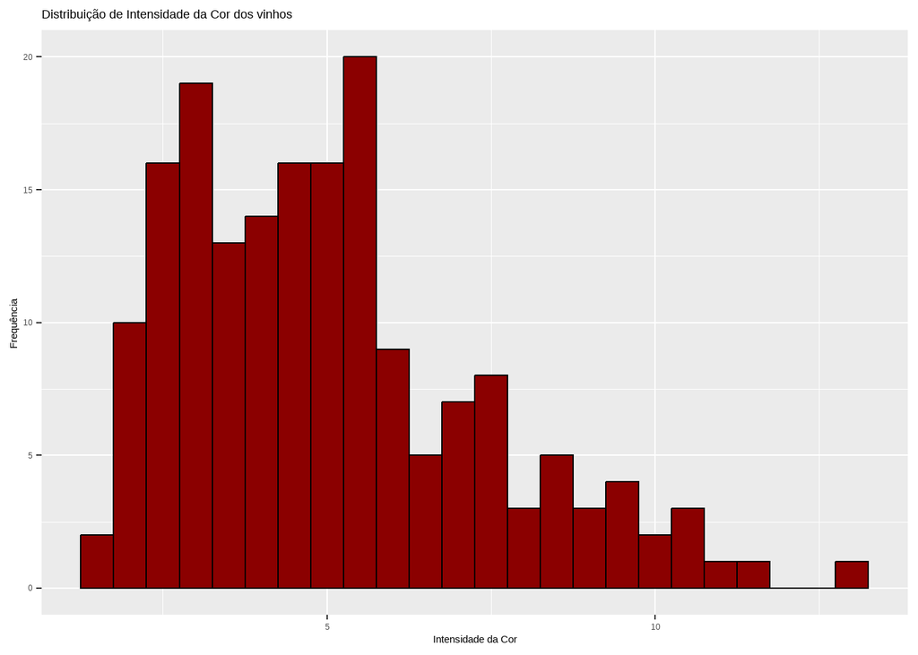

Pela distribuição das frequências, nota-se um agrupamento dos dados de intensidade da cor, no qual 70% dos dados possuem valores de até 5,7.

## Análise visual da variável Intensidade de cor

```r
sr <- function(x) {
  n <-length(x)
  return((3.49*sd(x))/n^(1/3))
}

sr (wine$Color_Intensity)
```

```
## [1] 1.43831
```

## Análise visual da variável Intensidade de cor - leitura

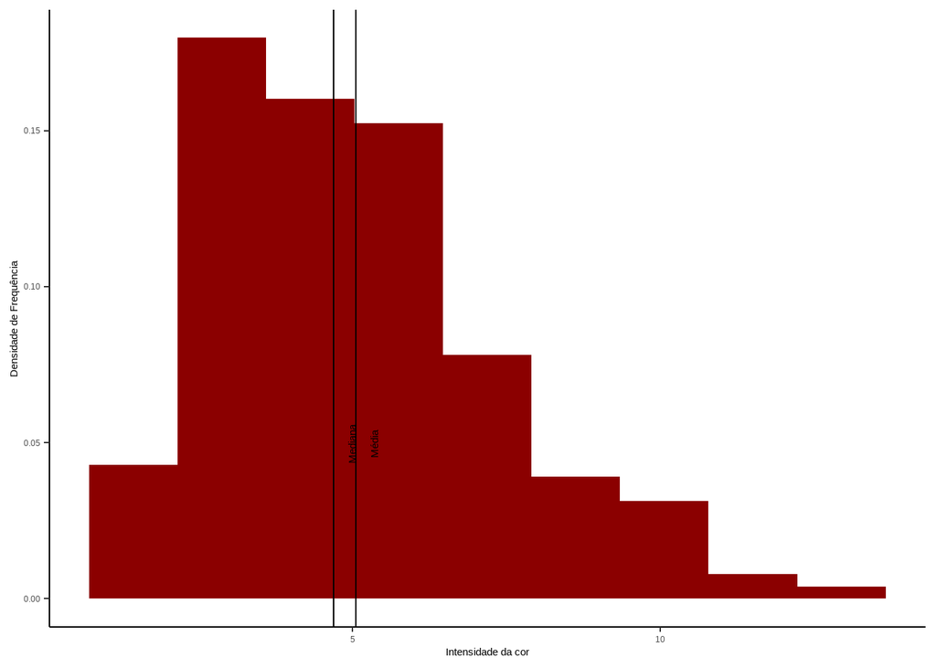

## Criando a Matriz de espalhamento

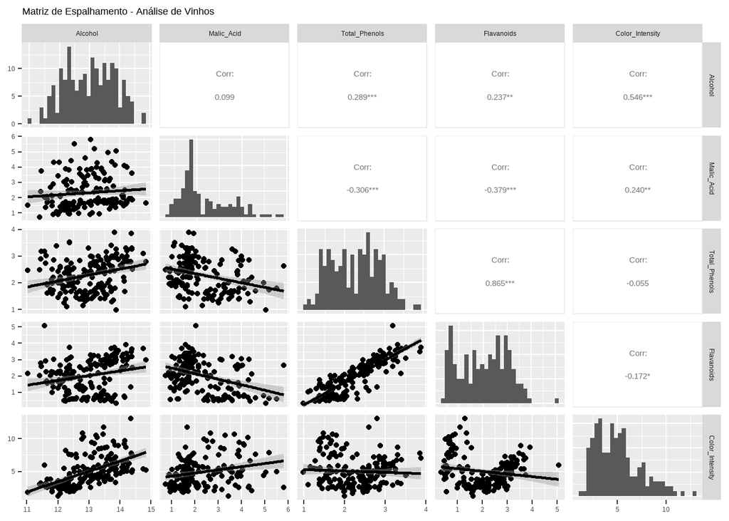

Assim como era esperado para Total_Phenol e Flavanoids, as variáveis possuem forte correlação positiva, com coeficiente de correlação igual a 0,87 e um forte agrupamento dos dados em torno da reta, havendo indício de que à medida que aumenta o Total_Phenol do vinho, também pode-se aumentar os Flavanoids.

## Distruição dos dados

A distribuição normal, também chamada de distribuição gaussiana, é uma das formas de distribuição de probabilidade que descreve como os dados tendem a se agrupar em torno de uma média, seguindo um padrão simétrico e bem definido. Nesse tipo de distribuição, o lado direito é uma imagem espelhada do lado esquerdo e a medida que os valores se afastam da média tendem a ser menos frequentes.

## Gráfico Quartil-Quartil (Q-Q)

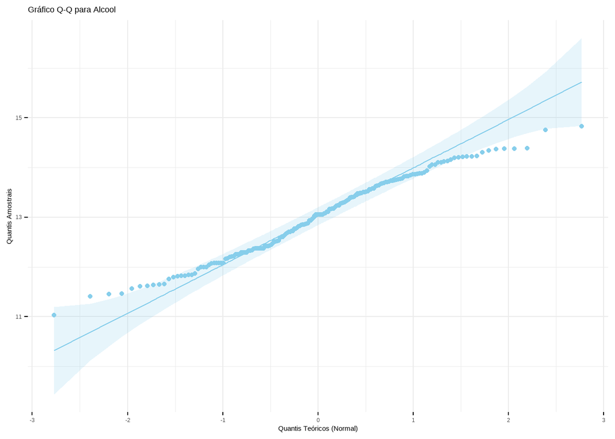

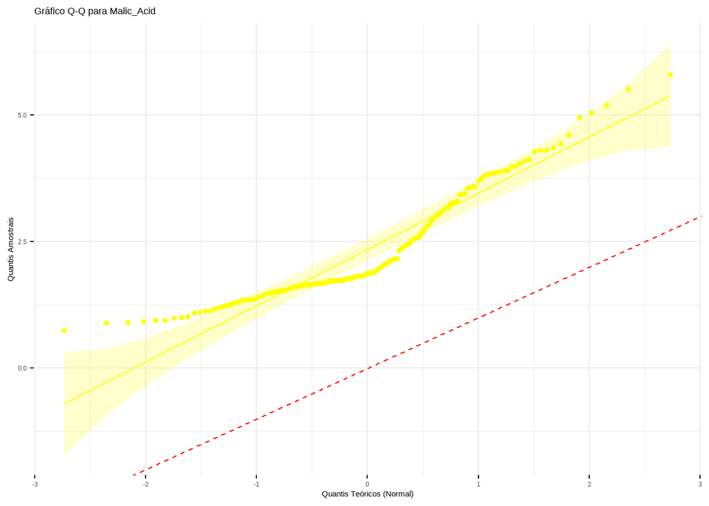

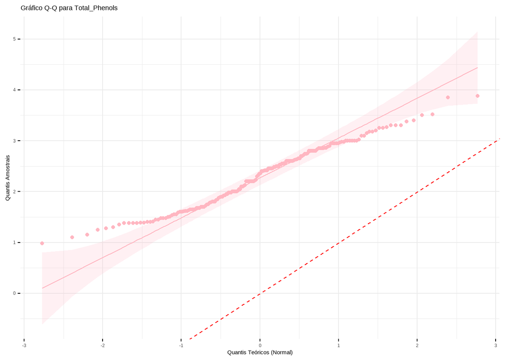

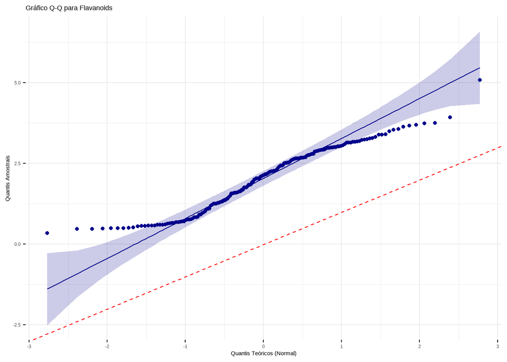

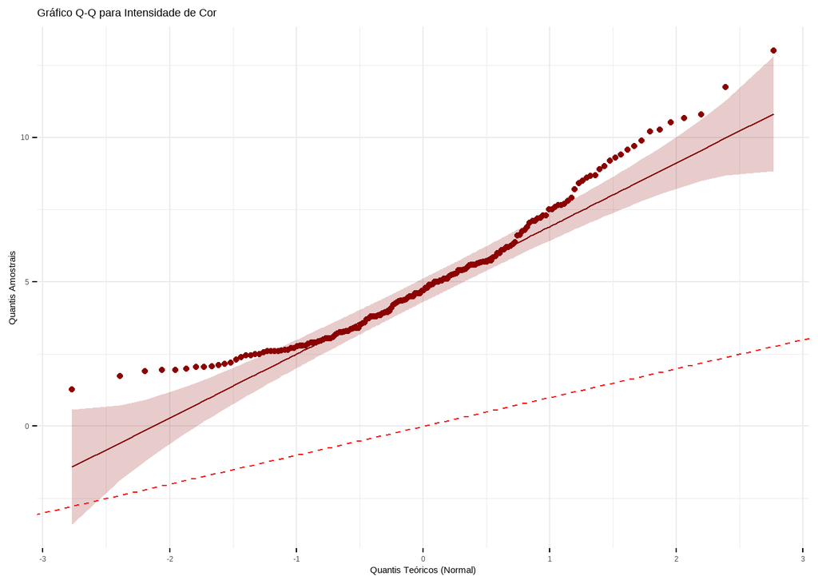

## Shapiro-test

o teste de Shapiro-Wilk é uma técnica estatística usada para avaliar a normalidade dos dados.

O shapiro-test para Alcohol e Total_Phenols, retornaram p-value de 0.02 e 0.004, respectivamente. Como os valores são inferiores a 0.05, as variãveis não possuem distribução normal.

```
Shapiro-Wilk normality test
```

data: wine$Alcohol W = 0.9818, p-value = 0.02005

```
Shapiro-Wilk normality test
```

data: wine$Total_Phenols W = 0.97668, p-value = 0.004395

## Completude de dados

A completude de dados refere-se à ausência de valores (missing values) em um conjunto de dados. Na análise exploratória de dados, a presença de dados faltantes pode impactar nas respostas e nos insights obtidos no estudo, refletindo na tomada de decisões e nas aplicações das informações. Em uma base com falta de completude, os resultados podem conter viés (quando os dados omitidos não forem aleatórios), reduzir a significância estatística (pela exlusão do tamanho da amostra), apresentar divergências nas métricas e trazer prejuízos na construção de modelos estatísticos.

## Imputação de Dados e MICE (Multiple Imputation by Chained Equations)

A imputação de dados é o processo de preencher valores faltantes em um conjunto de dados baseadO em padrões observados.

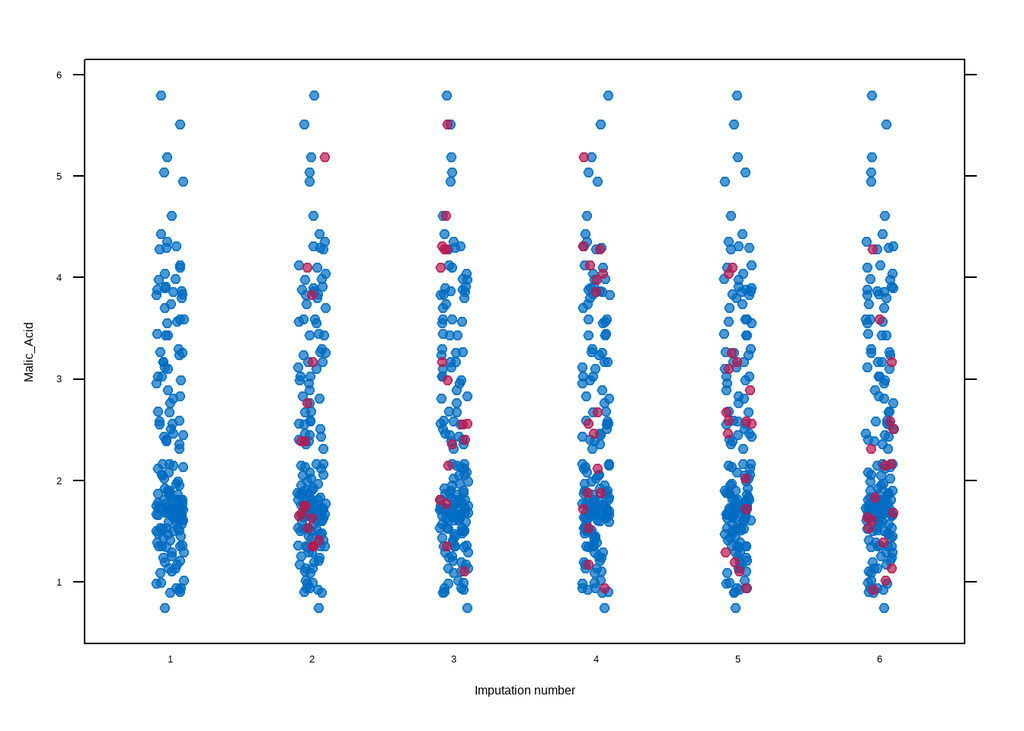

Min. 1st Qu. Median Mean 3rd Qu. Max. 0.740 1.593 1.845 2.328 3.083 5.800

## Verificando a base de **álcool** com os dados faltantes de **ácido málico**

Nota-se que mesmo com dados faltantes em ácido málico, a perda de informação está bem distribuída para todos os valores de Alcool, não existindo a presença de concentração de dados faltantes nos subconjuntos (agrupados pela frequência) da variável analisada.

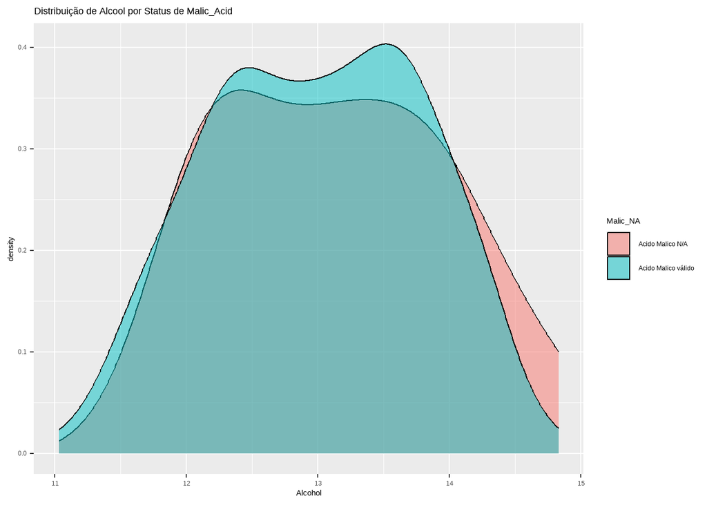

### Dashboard Shiny

[figure not shown]

Dashboard

### Links

Acesse o trabalho publicado no GitHub: [GitHub](https://github.com/mclarax/infnet)